# BellaBeat Leaf Case Study

Yash Naik

8/18/2021

# BellaBeat Product Analysis : Leaf wearable

## Deliverables

- A clear summary of the business task
- A description of all data sources used
- Documentation of any cleaning or manipulation of data
- A summary of your analysis
- Supporting visualizations and key findings
- Your top high-level content recommendations based on your analysis

## Business Task

In this project I will analyze smart device usage data in order to gain insight into how consumers use non-Bellabeat smart devices. I will then select one Bellabeat product to apply these insights to, in my presentation.

## Data Source

[FitBit Fitness Tracker Data](https://www.kaggle.com/arashnic/fitbit) (CC0: Public Domain, dataset made available through Mobius):

This Kaggle data set contains personal fitness tracker from thirty fitbit users. Thirty eligible Fitbit users consented to the submission of personal tracker data, including minute-level output for physical activity, heart rate, and sleep monitoring. It includes information about daily activity, steps, and heart rate that can be used to explore users’ habits.

```r
#install.packages("tidyverse")
library(tidyverse)
```

```r
#install.packages("dplyr")
library(dplyr)

#install.packages("ggplot2")
library(ggplot2)
```

## Downloaded Datasets

Leaf wearable devices is women-centric device primarily designed to track their activities, sleep schedules, hydration levels, hygene, etc. I will be analyzing Fitbit smart wearable device which provides tracking of some of the similar activities if not all. So, I have included these below mentioned datasets for my analysis.

- dailyActivity_merged
- dailySteps_merged
- minuteSleep_merged
- sleepDay_merged

#### Explore the datasets

```r
head(sleep_log)
```

```
## # A tibble: 6 × 5
##           Id SleepDay              TotalSleepRecor… TotalMinutesAsl… TotalTimeInBed
##        <dbl> <chr>                            <dbl>            <dbl>          <dbl>
## 1 1503960366 4/12/2016 12:00:00 AM                1              327            346
## 2 1503960366 4/13/2016 12:00:00 AM                2              384            407
## 3 1503960366 4/15/2016 12:00:00 AM                1              412            442
## 4 1503960366 4/16/2016 12:00:00 AM                2              340            367
## 5 1503960366 4/17/2016 12:00:00 AM                1              700            712
## 6 1503960366 4/19/2016 12:00:00 AM                1              304            320
```

```r
head(activity_log)
```

```
## # A tibble: 6 × 15
##           Id ActivityDate TotalSteps TotalDistance TrackerDistance LoggedActivitie…
##        <dbl> <chr>             <dbl>         <dbl>           <dbl>            <dbl>
## 1 1503960366 4/12/2016         13162          8.5             8.5                 0
## 2 1503960366 4/13/2016         10735          6.97            6.97                0
## 3 1503960366 4/14/2016         10460          6.74            6.74                0
## 4 1503960366 4/15/2016          9762          6.28            6.28                0
## 5 1503960366 4/16/2016         12669          8.16            8.16                0
## 6 1503960366 4/17/2016          9705          6.48            6.48                0
## # … with 9 more variables: VeryActiveDistance <dbl>,
## #   ModeratelyActiveDistance <dbl>, LightActiveDistance <dbl>,
## #   SedentaryActiveDistance <dbl>, VeryActiveMinutes <dbl>,
## #   FairlyActiveMinutes <dbl>, LightlyActiveMinutes <dbl>,
## #   SedentaryMinutes <dbl>, Calories <dbl>
```

```r
head(steps_log)
```

```
## # A tibble: 6 × 3
##           Id ActivityDay StepTotal
##        <dbl> <chr>           <dbl>
## 1 1503960366 4/12/2016       13162
## 2 1503960366 4/13/2016       10735
## 3 1503960366 4/14/2016       10460
## 4 1503960366 4/15/2016        9762
## 5 1503960366 4/16/2016       12669
## 6 1503960366 4/17/2016        9705
```

```r
head(sleep_minutes)
```

```
## # A tibble: 6 × 4
##           Id date                 value       logId
##        <dbl> <chr>                <dbl>       <dbl>
## 1 1503960366 4/12/2016 2:47:30 AM     3 11380564589
## 2 1503960366 4/12/2016 2:48:30 AM     2 11380564589
## 3 1503960366 4/12/2016 2:49:30 AM     1 11380564589
## 4 1503960366 4/12/2016 2:50:30 AM     1 11380564589
## 5 1503960366 4/12/2016 2:51:30 AM     1 11380564589
## 6 1503960366 4/12/2016 2:52:30 AM     1 11380564589
```

Checking the maximum and minimum distance values in activity dataset to look for potential outliers

```r
max(activity_log$TrackerDistance)
```

```
## [1] 28.03
```

```r
min(activity_log$TrackerDistance)
```

```
## [1] 0
```

```r
max(sleep_log$TotalMinutesAsleep)
```

```
## [1] 796
```

```r
min(sleep_log$TotalMinutesAsleep)
```

```
## [1] 58
```

We can observe that minimum value for TrackerDistance is 0 which is an indication to examine further.

```r
activity_log %>% count(activity_log$TrackerDistance == 0)
```

```
## # A tibble: 2 × 2
##   `activity_log$TrackerDistance == 0`     n
##   <lgl>                               <int>
## 1 FALSE                                 862
## 2 TRUE                                   78
```

```r
activity_filtered <- activity_log %>%
  filter(activity_log$TrackerDistance != 0)

head(activity_filtered)
```

```
## # A tibble: 6 × 15
##           Id ActivityDate TotalSteps TotalDistance TrackerDistance LoggedActivitie…
##        <dbl> <chr>             <dbl>         <dbl>           <dbl>            <dbl>
## 1 1503960366 4/12/2016         13162          8.5             8.5                 0
## 2 1503960366 4/13/2016         10735          6.97            6.97                0
## 3 1503960366 4/14/2016         10460          6.74            6.74                0
## 4 1503960366 4/15/2016          9762          6.28            6.28                0
## 5 1503960366 4/16/2016         12669          8.16            8.16                0
## 6 1503960366 4/17/2016          9705          6.48            6.48                0
## # … with 9 more variables: VeryActiveDistance <dbl>,
## #   ModeratelyActiveDistance <dbl>, LightActiveDistance <dbl>,
## #   SedentaryActiveDistance <dbl>, VeryActiveMinutes <dbl>,
## #   FairlyActiveMinutes <dbl>, LightlyActiveMinutes <dbl>,
## #   SedentaryMinutes <dbl>, Calories <dbl>
```

Next, we will calculate summary statistics of the filtered activity data and create different levels for activity.

```r
summary_activity <- activity_filtered %>%
  group_by(Id) %>%
  summarize(total_dist = sum(TrackerDistance), avg_dist = mean(TrackerDistance),
            num_dist = length(TrackerDistance))

summary_activity$distance_level <- case_when(
  summary_activity$avg_dist >= 8 ~ "Highly Active",
  summary_activity$avg_dist >= 4 ~ "Moderately Active",
  summary_activity$avg_dist >= 1 ~ "lowly Actively",
  summary_activity$avg_dist < 1 ~ "inactive"
)

head(summary_activity)
```

```
## # A tibble: 6 × 5
##           Id total_dist avg_dist num_dist distance_level
##        <dbl>      <dbl>    <dbl>    <int> <chr>
## 1 1503960366      242.      8.07       30 Highly Active
## 2 1624580081      121.      3.91       31 lowly Actively
## 3 1644430081      159.      5.30       30 Moderately Active
## 4 1844505072       52.9     2.64       20 lowly Actively
## 5 1927972279       19.7     1.16       17 lowly Actively
## 6 2022484408      251.      8.08       31 Highly Active
```

Creating a scatter plot to verify if there is any positive correlation between tracking distance and average distance.

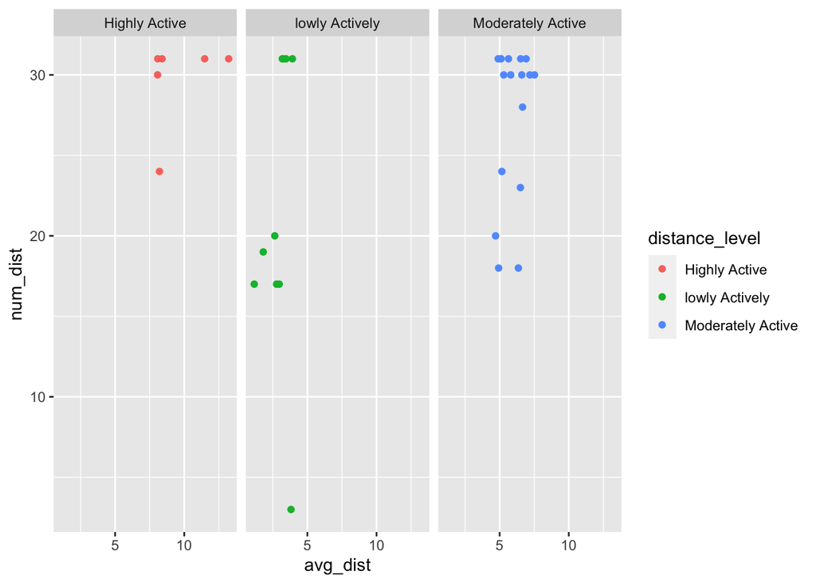

```r
ggplot(data=summary_activity) + geom_point(aes(x = avg_dist, y = num_dist,
                                               color= distance_level)) +
  facet_wrap(~distance_level)
```

From the plot above, we can observe a *little* *positive* *correlation* between tracking entries and average distance covered. All the users who are highly active have logged their entries more than 20 times. Similarly, moderately active users, have comparatively more tracking entries than lowly_active users.

Now, we can extend our analysis to dig deeper and check if users who are highly active, have slept for longer.

```r
summary_sleep <- sleep_log %>%
  group_by(Id) %>%
  summarize(total_sleep_min = sum(TotalMinutesAsleep), average_sleep_min = mean(TotalMinutesAsleep), num_sleep_entries = length(TotalMinutesAsleep))

summary_sleep$sleep_levels <- case_when(
  summary_sleep$average_sleep_min >= 480 ~ "Well Rested",
  summary_sleep$average_sleep_min >= 360 ~ "Moderately Rested",
  summary_sleep$average_sleep_min >= 240 ~ "Poorly Rested",
  summary_sleep$average_sleep_min < 240 ~ "Not Rested"
)

head(summary_sleep)
```

```
## # A tibble: 6 × 5
##           Id total_sleep_min average_sleep_min num_sleep_entries sleep_levels
##        <dbl>           <dbl>             <dbl>             <int> <chr>
## 1 1503960366            9007              360.                25 Moderately Res…
## 2 1644430081            1176              294                  4 Poorly Rested
## 3 1844505072            1956              652                  3 Well Rested
## 4 1927972279            2085              417                  5 Moderately Res…
## 5 2026352035           14173              506.                28 Well Rested
## 6 2320127002              61               61                  1 Not Rested
```

Now, we will again create a scatter plot to check for any correlation between average sleep and number of sleep entries.

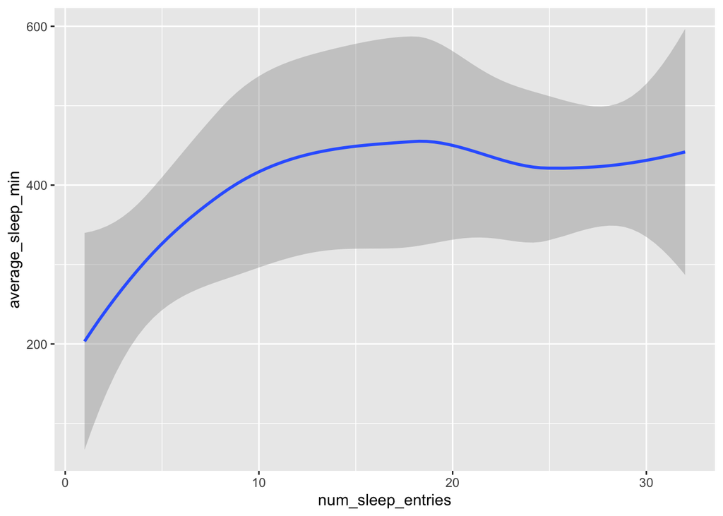

```r
ggplot(data = summary_sleep) + geom_smooth(aes(x = num_sleep_entries, y = average_sleep_min))
```

Yes, we can observe a *positive* *correlation* between users who have more sleep entries and the number of hours they have slept.

### To analyse a pattern between activity and sleep, we can combine the two summary dataframes.

Combining *summary_activity* and *summary_sleep* to create a single dataframe.

```r
activity_sleep <- merge(summary_activity, summary_sleep, by = 'Id')

head(activity_sleep)
```

```
##           Id total_dist avg_dist num_dist    distance_level total_sleep_min
## 1 1503960366     242.10 8.070000       30     Highly Active            9007
## 2 1644430081     158.86 5.295333       30 Moderately Active            1176
## 3 1844505072      52.89 2.644500       20    lowly Actively            1956
## 4 1927972279      19.67 1.157059       17    lowly Actively            2085
## 5 2026352035     107.10 3.454839       31    lowly Actively           14173
## 6 2320127002      98.82 3.187742       31    lowly Actively              61
##   average_sleep_min num_sleep_entries      sleep_levels
## 1          360.2800                25 Moderately Rested
## 2          294.0000                 4     Poorly Rested
## 3          652.0000                 3       Well Rested
## 4          417.0000                 5 Moderately Rested
## 5          506.1786                28       Well Rested
## 6           61.0000                 1        Not Rested
```

We will again visualize to check if there is any correlation between users who are highly active and who have slept for longer duration.

## Visualization

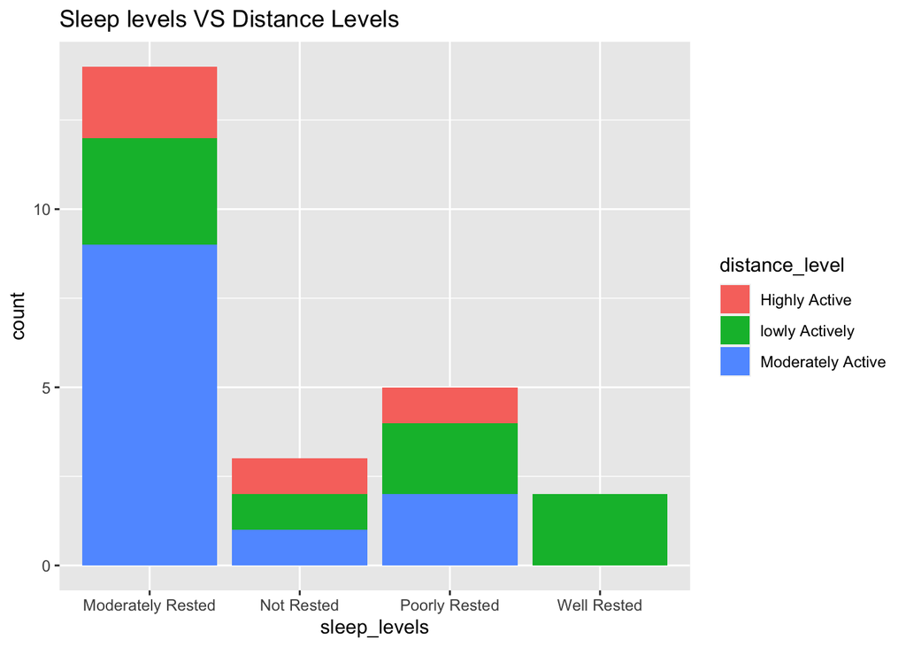

```r
ggplot(data= activity_sleep) + geom_bar(aes(x=sleep_levels, fill = distance_level)) +
  labs(title = "Sleep levels VS Distance Levels")
```

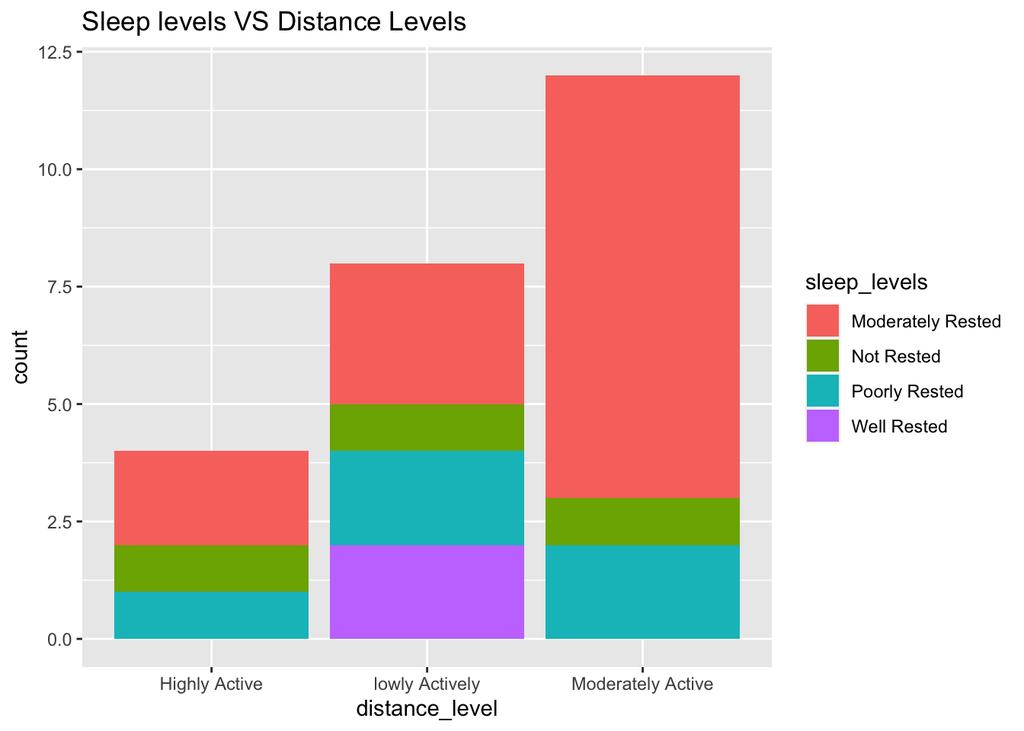

```r
ggplot(data= activity_sleep) + geom_bar(aes(x=distance_level, fill = sleep_levels)) +
  labs(title = "Sleep levels VS Distance Levels")
```

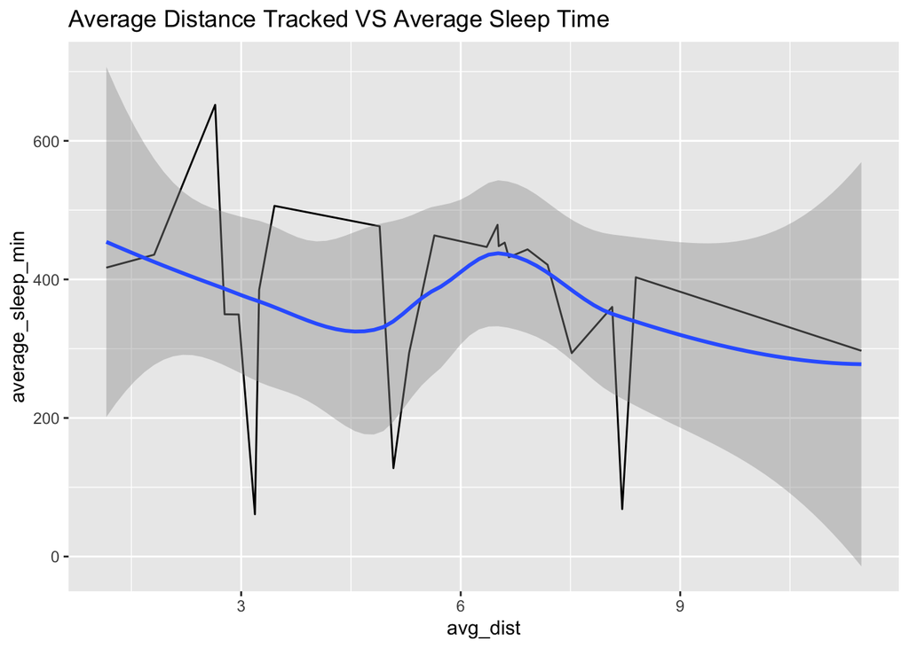

```r
ggplot(data = activity_sleep) +
   geom_line(aes(x=avg_dist, average_sleep_min))+
   geom_smooth(aes(x=avg_dist, average_sleep_min))+
   labs(title='Average Distance Tracked VS Average Sleep Time')
```

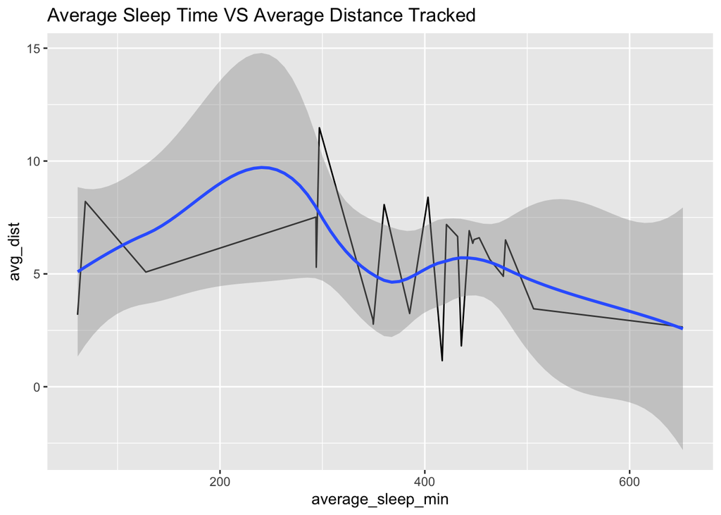

```r
ggplot(data=activity_sleep)+
  geom_line(aes(x=average_sleep_min, avg_dist))+
  geom_smooth(aes(x=average_sleep_min,y=avg_dist))+
  labs(title='Average Sleep Time VS Average Distance Tracked')
```

Initially, I thought there would be a strong positive correlation between average distance tracking and sleeping i.e. A person who is very actively should have rested for a longer duration than someone who is less active on an average. Looking at these trends, I am surprised that my assumption has been refuted as after visualizing these trends, it appears that there is *little* to *no* correlation between the two things.

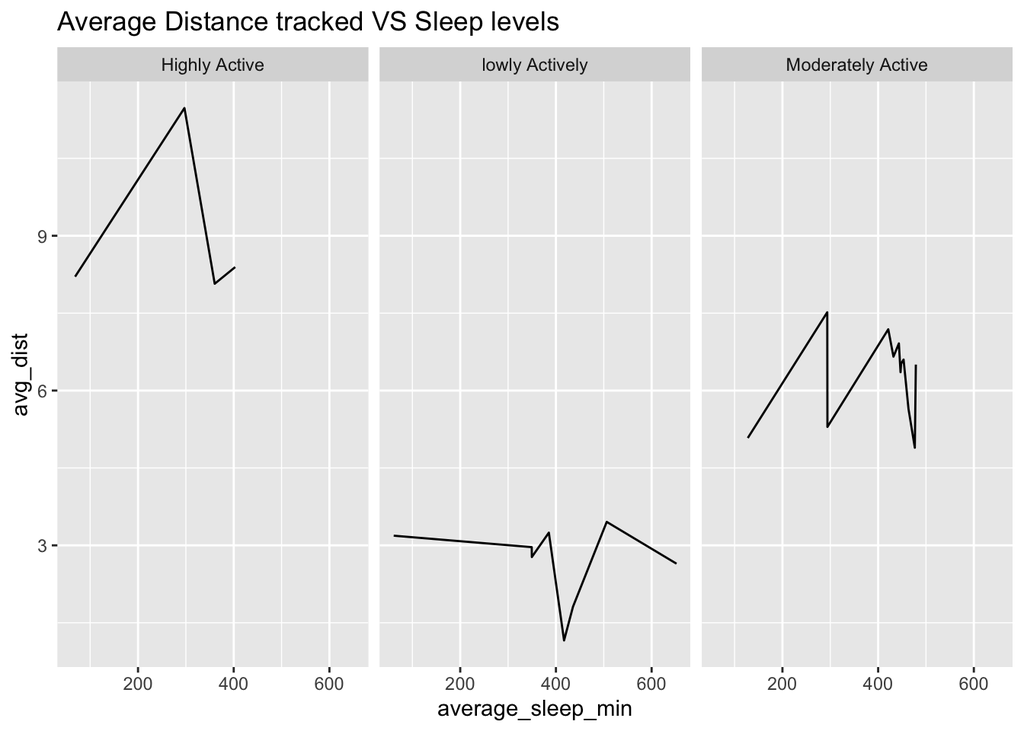

```r
ggplot(data = activity_sleep) + geom_line(aes(x = average_sleep_min, y = avg_dist))+
  labs(title = "Average Distance tracked VS Sleep levels")+
  facet_wrap(~distance_level)
```

## Recommendation

After analyzing the fitbit smart device in order to have its comparision with Bellabeat’s Leaf, I can conclude with the following recommedations-

** Increasing battery capacity to avoid discharge during the nights or decrease battery usage through *low power mode* etc.